# Multivariate Analysis Lecture 13: LDA

Zhaoxia Yu

Professor, Department of Statistic

2026-05-31

# Review of LDA

## Linear Discrminant Analysis

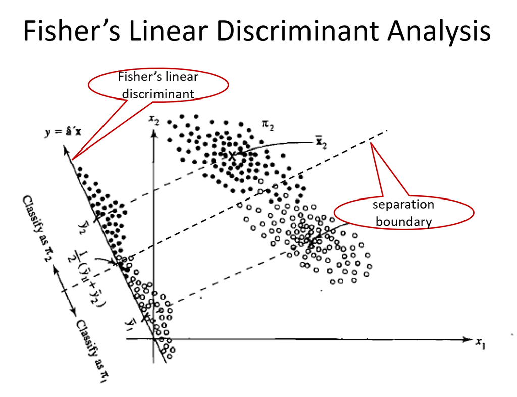

```r
knitr::include_graphics("img/FLDA.png")
```

## LDA for two classes (FLDA)

- Fisher 1936 proposed a dichotomous discriminant analysis
- FLDA looks for the linear function with the maximum ability to discriminant between samples
- Once we find the linear function, we
  - project the data on to it
  - find the boundary of different classes
  - allocate new observations

### FLDA: Assumptions

- A two-class classification problem with $n_1$ and $n_2$ observations in classes 1 and 2, respectively.
- Suppose we have two independent random samples
  - Sample 1: $X_{1j}\overset{iid}\sim (\mathbf \mu_1, \boldsymbol \Sigma)$, where $j=1, \cdots, n_1$
  - Sample 2: $X_{2j}\overset{iid}\sim (\mathbf \mu_2, \boldsymbol \Sigma)$, where $j=1, \cdots, n_2$
- Sample mean vectors:
  $$\bar {\mathbf X}_1=\frac{1}{n_1}\sum_{j=1}^{n_1}X_{1j},
  \bar {\mathbf X}_2=\frac{1}{n_2}\sum_{j=1}^{n_2}X_{2j}$$

### FLDA: The Goal

- How to define separability of a linear function?
- Consider a linear function with coefficients being denoted by a vector $a$.
  - $a^T\bar {\mathbf X}_1 \sim (a^T \mathbf \mu_1, \frac{1}{n_1}a^T\boldsymbol \Sigma a)$
  - $a^T\bar {\mathbf X}_2 \sim (a^T \mathbf \mu_2, \frac{1}{n_2}a^T\boldsymbol \Sigma a)$
- $a^T\bar {\mathbf X}_1 - a^T\bar {\mathbf X}_2$ measures the difference but the variation of this difference depends on the scale of $a$ and also the covariance structure
- We need to “standardize” it by its standard error

### FLDA: Maximum Separability

- Recall that we have two independent random samples. Therefore,
  $$(a^T\bar {\mathbf X}_1-a^T\bar {\mathbf X}_2) \sim \left(a^T \mathbf \mu_1- a^T \mathbf \mu_2, (\frac{1}{n_1} + \frac{1}{n_2})\boldsymbol a^T \Sigma a \right)$$
- The standardized version is
  $$\frac{a^T\bar {\mathbf X}_1-a^T\bar {\mathbf X}_2}{\sqrt{(\frac{1}{n_1} + \frac{1}{n_2})a^T\boldsymbol \Sigma a}}$$

### FLDA: Maximum Separability

- The sign does not matter. So we consider the squared statistic
  $$\frac{(a^T\bar {\mathbf X}_1-a^T\bar {\mathbf X}_2)^2}{(\frac{1}{n_1} + \frac{1}{n_2})a^T \boldsymbol \Sigma a}$$
- This is the squared t-statistic for testing $a^T\mathbf \mu_1=a^T\mathbf \mu_2$
- We look for $a$ that maximally separates the classes while minimizes the within-class variance. $\boldsymbol \Sigma$ should be estimated by the pooled sample covariance matrix $\mathbf S_p$.

### FLDA: Maximum Separability

- The maximization problem is
  $$\operatorname*{argmax}_a \frac{a^T(\bar {\mathbf X}_1 - \bar {\mathbf X}_2)(\bar {\mathbf X}_1 - \bar {\mathbf X}_2)^Ta}{a^T \boldsymbol \Sigma a}$$
- Use an argument similar to PCA, such $a$ is the first eigenvector of $\boldsymbol \Sigma ^{-1}(\bar {\mathbf X}_1 - \bar {\mathbf X}_2)(\bar {\mathbf X}_1 - \bar {\mathbf X}_2)^T$.
- We can show that $a=\mathbf S_p^{-1}(\bar {\mathbf X}_1 - \bar {\mathbf X}_2)$.
- The linear function
  $$f(x)=a^T x \mbox{ where } a=\mathbf S_p^{-1}(\bar {\mathbf X}_1 - \bar {\mathbf X}_2)$$
  is called Fisher’s linear discriminant function.

### Allocate New Observations

- Fisher’s linear discriminant function
  $$f(x)=a^T x \mbox{ where } a=\mathbf S_p^{-1}(\bar {\mathbf X}_1 - \bar {\mathbf X}_2).$$
- Projected mid-point
  $$m=a^T \frac{\bar {\mathbf X}_1 + \bar {\mathbf X}_2}{2}=\frac{1}{2}\boldsymbol (\bar {\mathbf X}_1 - \bar {\mathbf X}_2)^T \mathbf S_p^{-1}(\bar {\mathbf X}_1 + \bar {\mathbf X}_2)$$
- Consider an observation $x_0$. We allocate it to
  - class 1 if $f(x_0)>m$
  - class 2 if $f(x_0)<m$

## PCA vs LDA

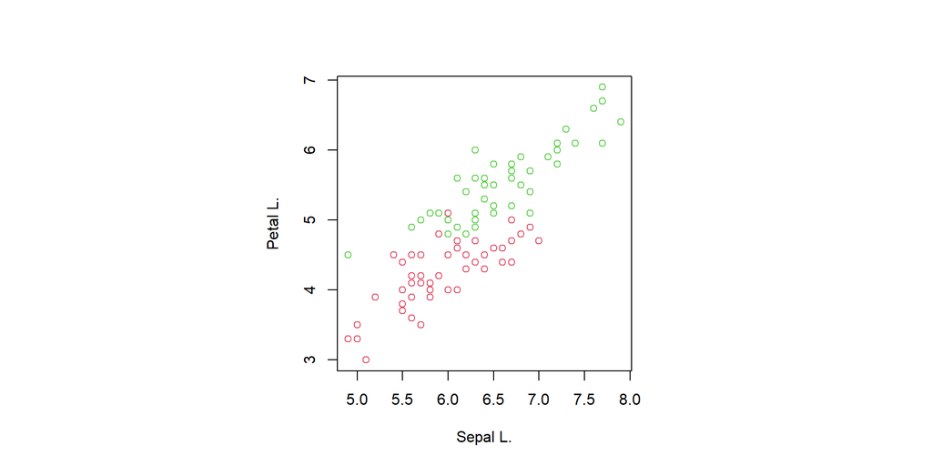

```r
sample1=iris3[,c(1,3),2]#Versicolor
sample2=iris3[,c(1,3),3]#Virginica
sample12=rbind(sample1, sample2)
pch=c("e","i"); col=c(2,3); xlab="SepalL"; ylab="PetalL"
par(pty="s")
plot(sample12,type="n")
points(sample1, col=col[1]); points(sample2, col=col[2])
```

### PCA vs LDA: Compute loadings

```r
n1=dim(sample1)[1]
n2=dim(sample2)[1]

#LDA
mean.diff=c( colMeans(sample1)-colMeans(sample2) )
data.center=c( (colMeans(sample1)+colMeans(sample2))/2 )
S.pooled=((n1-1)*cov(sample1)+(n2-1)*cov(sample2))/(n1+n2-2)
lda.coeff=solve(S.pooled)%*% mean.diff
#rescale it so that is has norm 1
lda.coeff=lda.coeff/sqrt(sum(lda.coeff^2))
m=c(t(lda.coeff)%*%data.center)
#PCA
pca.coeff=eigen(cov(sample12))$vector[,1]
#project data to LDA and PCA
proj.lda=(sample12%*%lda.coeff)%*%matrix(lda.coeff, 1,2)
proj.pca=(sample12%*%pca.coeff)%*%matrix(pca.coeff, 1,2)
```

- LDA loadings:

```r
lda.coeff
```

```
               [,1]
Sepal L.  0.4610660
Petal L. -0.8873658
```

- PCA: loadings of first PC

```r
pca.coeff
```

```
[1] 0.6090576 0.7931260
```

### Visualize the LDA Allocations

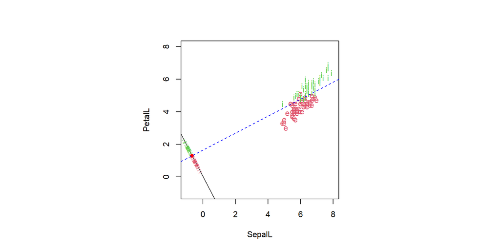

```r
proj.scalar=(sample12%*%lda.coeff)
par(pty="s")
plot(sample12, xlim=c(-1,8), ylim=c(-1,8), xlab=xlab, ylab=ylab, type="n")
points(sample1, pch=pch[1], col=col[1])
points(sample2, pch=pch[2], col=col[2])

abline(a=0, b=lda.coeff[2]/lda.coeff[1])
for(i in 1: (n1+n2)){
  if(proj.scalar[i]>m)
    text(x=proj.lda[i,1],y=proj.lda[i,2], labels="|", col=col[1],
         srt=atan(lda.coeff[2]/lda.coeff[1])*180/pi, cex=0.5)
  if(proj.scalar[i]<m)
    text(x=proj.lda[i,1],y=proj.lda[i,2], labels="|", col=col[2],
         srt=atan(lda.coeff[2]/lda.coeff[1])*180/pi, cex=0.5)
}
points(m*lda.coeff[1], m*lda.coeff[2], pch=16, col="red")
abline(a=m/lda.coeff[2], b=-lda.coeff[1]/lda.coeff[2], col="blue", lty=2)
```

### Project Data to LDA and PCA

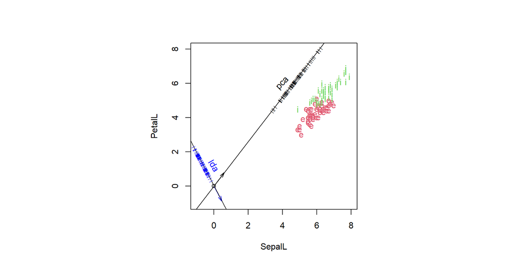

```r
proj.lda=(sample12%*%lda.coeff)%*%matrix(lda.coeff, 1,2)
proj.pca=(sample12%*%pca.coeff)%*%matrix(pca.coeff, 1,2)
par(pty="s")
plot(sample12, xlim=c(-1,8), ylim=c(-1,8), xlab=xlab, ylab=ylab, type="n")
points(sample1, pch=pch[1], col=col[1])
points(sample2, pch=pch[2], col=col[2])
points(0, 0)
arrows(0, 0, lda.coeff[1], lda.coeff[2], length = 0.1, angle=15, col="blue")
abline(a=0, b=lda.coeff[2]/lda.coeff[1])
arrows(0, 0, pca.coeff[1], pca.coeff[2], length = 0.1, angle=15, col="black")
abline(a=0, b=pca.coeff[2]/pca.coeff[1])
for(i in 1: (n1+n2)){
  text(x=proj.lda[i,1],y=proj.lda[i,2], labels="|", col="blue",
       srt=atan(lda.coeff[2]/lda.coeff[1])*180/pi, cex=0.5)
  text(x=proj.pca[i,1],y=proj.pca[i,2], labels="|", col="black",
       srt=atan(pca.coeff[2]/pca.coeff[1])*180/pi, cex=0.5)}
text(x=0, y=1.2, "lda", srt=-60, col="blue")
text(x=4, y=6, "pca", srt=45, col="black")
```

### LDA from R

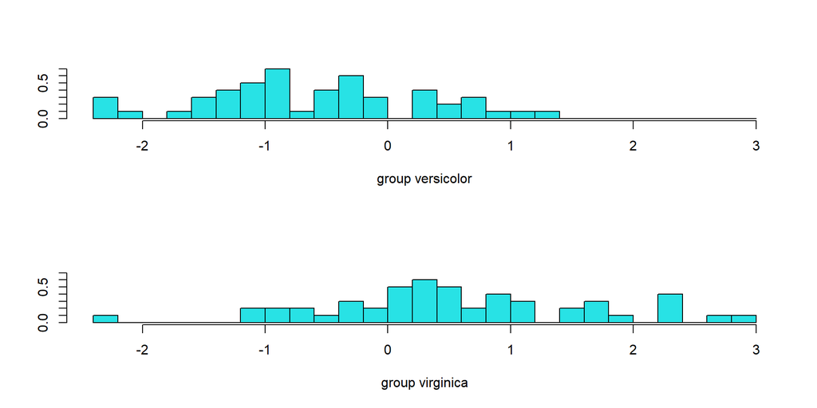

```r
#function lda is from MASS library
lda.iris = lda(Species ~ ., data = iris[51:150, c(1,2,5)])
plot(lda.iris)
```

- Confusion matrix

```r
pred = predict(lda.iris)

# confusion matrix
table(True = iris[51:150, 5], Predicted = pred$class)
```

```
            Predicted
True         setosa versicolor virginica
  setosa          0          0         0
  versicolor      0         38        12
  virginica       0         13        37
```

- Training error rate

```r
# training error rate
mean(pred$class != iris[51:150, 5])
```

```
[1] 0.25
```

- The `lda` function in MASS library has a built-in option to do leave-one-out cross validation.

```r
lda.cv = lda(Species ~ ., data = iris[51:150, c(1,2,5)], CV = TRUE)
table(True = iris[51:150, 5],
  Predicted = lda.cv$class)
```

```
            Predicted
True         setosa versicolor virginica
  setosa          0          0         0
  versicolor      0         38        12
  virginica       0         15        35
```

```r
mean(lda.cv$class != iris[51:150, 5])
```

```
[1] 0.27
```

- Need to write code or use other packages to do k-fold cross validation.

# Three-Class LDA

## Three-Class Classification

- Using the same strategy, we can construct linear discriminants for a three-class problem
- Suppose there are $3$ independent random samples
  - sample sizes $n_1, n_2, n_3$
  - mean vectors $\boldsymbol \mu_1, \boldsymbol \mu_2, \boldsymbol \mu_3$
  - a common covariance matrix $\boldsymbol \Sigma$

## The Linear Discriminants

- Sample mean vectors: $\bar {\mathbf X}_1, \bar {\mathbf X}_2, \bar {\mathbf X}_3$
- Pooled sample covariance
  $$\mathbf S_{p} =\frac{(n_1-1)S_1 + (n_2-1)S_2 + (n_3-1)S_3}{n_1+n_2+n_3-3}$$
- Let $a_{12}$, $a_{13}$, and $a_{23}$ denote the linear discriminants for the three pairs, respectively
- Let $m_{12}$, $m_{13}$, and $m_{23}$ denote the projected centers

## The Linear Discriminants

- Following from FLDA, we have
  $$a_{ij}=\mathbf S_p^{-1}(\bar {\mathbf X}_i - \bar {\mathbf X}_j),
  m_{ij}=a_{ij}^T \frac{\bar {\mathbf X}_i + \bar {\mathbf X}_j}{2}$$
- The three linear boundaries are given by the three equations
  $$f_{ij}(x)=a_{ij}^T x = m_{ij}$$

## Allocate New Observations

- Let $X_0$ be a new observation
- We allocate $X_0$ to
  - class 1 if $f_{12}(X_0)>m_{12}$ and $f_{13}(X_0)>m_{13}$
  - class 2 if $f_{23}(X_0)>m_{23}$ and $f_{12}(X_0)<m_{12}$
  - class 3 if $f_{13}(X_0)<m_{13}$ and $f_{23}(X_0)<m_{23}$

## Minimum Distance Approach

- Following the argument we used for minimum distance in the two-class problem, the allocation rule in the previous slide is equivalent to allocate $X_0$ to
  - class 1 if $D_{S_p}(X_0, \bar {\mathbf X}_1) < D_{S_p}(X_0, \bar {\mathbf X}_2)$ and $D_{S_p}(X_0, \bar {\mathbf X}_1) < D_{S_p}(X_0, \bar {\mathbf X}_3)$
  - class 2 if $D_{S_p}(X_0, \bar {\mathbf X}_2) < D_{S_p}(X_0, \bar {\mathbf X}_1)$ and $D_{S_p}(X_0, \bar {\mathbf X}_2) < D_{S_p}(X_0, \bar {\mathbf X}_3)$
  - class 3 if $D_{S_p}(X_0, \bar {\mathbf X}_3) < D_{S_p}(X_0, \bar {\mathbf X}_1)$ and $D_{S_p}(X_0, \bar {\mathbf X}_3) < D_{S_p}(X_0, \bar {\mathbf X}_2)$
- In summary, we allocate $X_0$ to the group with the minimum Mahalanobis distance.

## Maximum Likelihood Approach

- Again, following the argument used in the two-class problem, we allocate $X_0$ to
  - class 1 if $\frac{L_1}{L_2}>1$ and $\frac{L_1}{L_3}>1$
  - class 2 if $\frac{L_2}{L_3}>1$ and $\frac{L_2}{L_3}>1$
  - class 3 if $\frac{L_3}{L_1}>1$ and $\frac{L_3}{L_2}>1$
- Therefore, the LDA is equivalent to the maximum likelihood approach.

# Example: Iris data with 3 classes, 2 Features

## Iris Data: three species, two features: SL SW

- Visualize the data

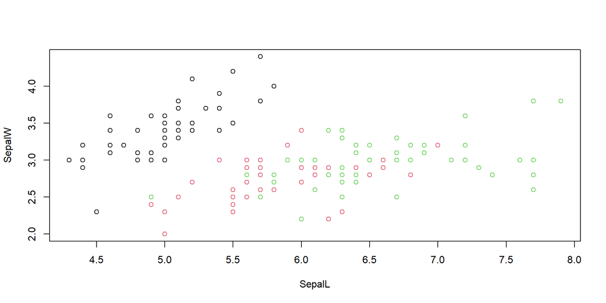

```r
i=1; j=2 #(SpealL and Sepal W)
plot(iris3[,i,1], iris3[,j,1], xlim=c(min(iris3[,i,]),max(iris3[,i,])), xlab="SepalL", ylab="SepalW",
ylim=c(min(iris3[,j,]),max(iris3[,j,])))
points(iris3[,i,2], iris3[,j,2], col=2)
points(iris3[,i,3], iris3[,j,3], col=3)
```

### Compute linear discriminants and projected centers

- compute the linear discriminants and the projected centers for the three pairs of classes

$$\begin{aligned}
f_{12}(x)=&a_{12}^T x = m_{12}\\
f_{13}(x)=&a_{13}^T x = m_{13}\\
f_{23}(x)=&a_{23}^T x = m_{23}
\end{aligned}$$

- For each $(i,j)$ pair, the linear discriminant is a line with slope $-a_{ij}[1]/a_{ij}[2]$ and intercept $m_{ij}/a_{ij}[2]$ because
  $$a_{ij}[1] * SL + a_{ij}[2] SW = m_{ij}$$

```r
i=1; j=2 #(SpealL and Sepal W)
s.pooled=((50-1)*cov(iris3[,c(i,j),1]) +
            (50-1)*cov(iris3[,c(i,j),2])+
            (50-1)*cov(iris3[,c(i,j),3]))/(150-3)
x1.bar=colMeans(iris3[,c(i,j),1])
x2.bar=colMeans(iris3[,c(i,j),2])
x3.bar=colMeans(iris3[,c(i,j),3])
a12=c(solve(s.pooled)%*%(x1.bar-x2.bar))
a13=c(solve(s.pooled)%*%(x1.bar-x3.bar))
a23=c(solve(s.pooled)%*%(x2.bar-x3.bar))
a12=a12/sqrt(sum(a12^2)); m12=c(a12%*%(x1.bar+x2.bar)/2)
a13=a13/sqrt(sum(a13^2)); m13=c(a13%*%(x1.bar+x3.bar)/2)
a23=a23/sqrt(sum(a23^2)); m23=c(a23%*%(x2.bar+x3.bar)/2)
```

### Visualize data and linear discriminants

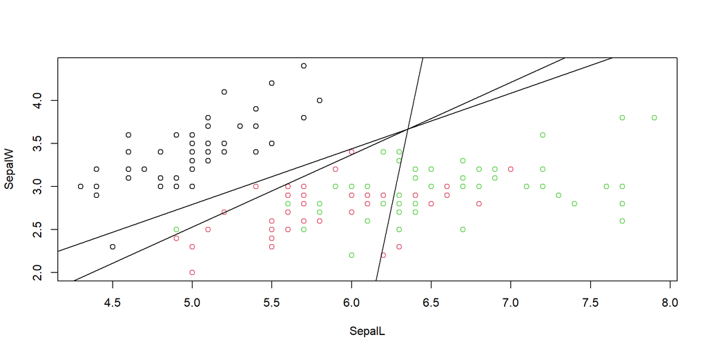

```r
plot(iris3[,i,1], iris3[,j,1], xlim=c(min(iris3[,i,]),max(iris3[,i,])), xlab="SepalL", ylab="SepalW",
ylim=c(min(iris3[,j,]),max(iris3[,j,])))
points(iris3[,i,2], iris3[,j,2], col=2)
points(iris3[,i,3], iris3[,j,3], col=3)
abline(m12/a12[2], -a12[1]/a12[2])
abline(m13/a13[2], -a13[1]/a13[2])
abline(m23/a23[2], -a23[1]/a23[2])
```

### Remove extra lines

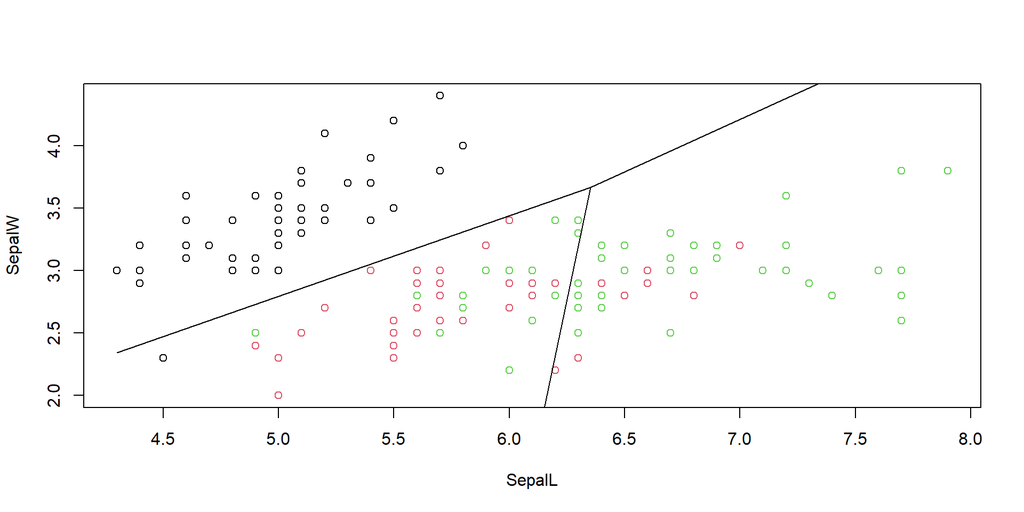

```r
# slopes
k12=a12[2]/a12[1]
k13=a13[2]/a13[1]
k23=a23[2]/a23[1]

# the joint point
joint.point=solve(rbind(a12,a13))%*%c(m12,m13) # point at which the three lines cross

### remove extra lines
plot(iris3[,i,1], iris3[,j,1], xlim=c(min(iris3[,i,]),max(iris3[,i,])), xlab="SepalL", ylab="SepalW",
ylim=c(min(iris3[,j,]),max(iris3[,j,])))
points(iris3[,i,2], iris3[,j,2], col=2)
points(iris3[,i,3], iris3[,j,3], col=3)
#classes 1 vs 2
lines(
c(min(iris3[,i,]), joint.point[1]),
c(1/k12*(x1.bar[1]+x2.bar[1])/2 + (x1.bar[2]+x2.bar[2])/2 -min(iris3[,i,])/k12,
1/k12*(x1.bar[1]+x2.bar[1])/2 + (x1.bar[2]+x2.bar[2])/2 -joint.point[1]/k12))

#classes 1 vs 3
lines(
c(joint.point[1],max(iris3[,i,])),
c(1/k13*(x1.bar[1]+x3.bar[1])/2 + (x1.bar[2]+x3.bar[2])/2 -joint.point[1]/k13,
1/k13*(x1.bar[1]+x3.bar[1])/2 + (x1.bar[2]+x3.bar[2])/2 -max(iris3[,i,])/k13))

#classes 2 vs 3
lines(
c(min(iris3[,i,]), joint.point[1]),
c(1/k23*(x2.bar[1]+x3.bar[1])/2 + (x2.bar[2]+x3.bar[2])/2 -min(iris3[,i,])/k23,
1/k23*(x2.bar[1]+x3.bar[1])/2 + (x2.bar[2]+x3.bar[2])/2 -joint.point[1]/k23))
```

## The Three Boundaries Meet at Same Point

- The linear discriminants for groups (1,2) and (1,3) are:
  $$\begin{aligned}
  (\bar {\mathbf X}_1 - \bar {\mathbf X}_2)^T \boldsymbol \Sigma^{-1} x
  &= \frac{1}{2}
  (\bar {\mathbf X}_1 - \bar {\mathbf X}_2)^T \boldsymbol \Sigma^{-1}(\bar {\mathbf X}_1 + \bar {\mathbf X}_2)\\
  (\bar {\mathbf X}_1 - \bar {\mathbf X}_3)^T \boldsymbol \Sigma^{-1} x
  &= \frac{1}{2}
  (\bar {\mathbf X}_1 - \bar {\mathbf X}_3)^T \boldsymbol \Sigma^{-1}(\bar {\mathbf X}_1 + \bar {\mathbf X}_3)
  \end{aligned}$$
- Subtracting the first equation from the second equation

- The result indicates that the three lines meet at the same point

### Classification Performance

```r
lda.iris = lda(Species ~ ., data = iris[, c(1,2,5)])
con.mat=table(Pred = predict(lda.iris, iris[, c(1,2,5)])$class,
              True = iris$Species)
#Confusion Matrix
con.mat
```

```
            True
Pred         setosa versicolor virginica
  setosa         49          0         0
  versicolor      1         36        15
  virginica       0         14        35
```

```r
#Training Error
1-sum(diag(con.mat))/sum(con.mat)
```

```
[1] 0.2
```

## Visualizing the two linear discriminants

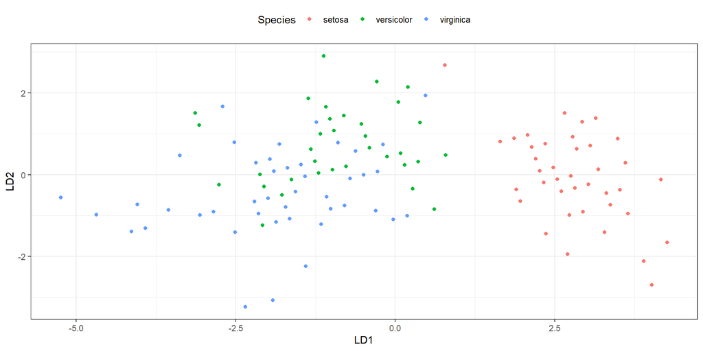

```r
lda.iris.data=data.frame(Species=iris$Species, predict(lda.iris, iris)$x)
ggplot(lda.iris.data, aes(x=LD1, y=LD2, color=Species)) +
  geom_point() +
  labs(x="LD1", y="LD2") +
  theme_bw() +
  theme(legend.position = "top")
```

## Visualization using partimat function in klaR package

```r
library(klaR)
partimat(Species ~ Sepal.Length + Sepal.Width, data = iris, method = "lda")
```

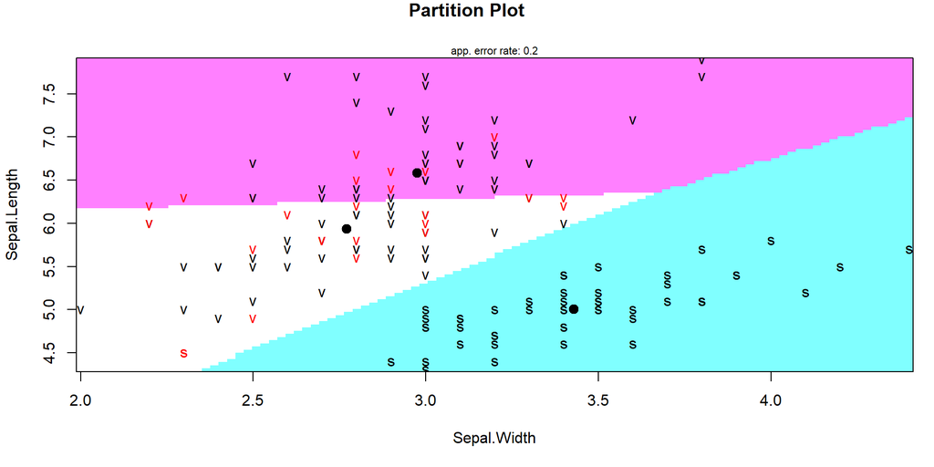

# Example: Iris 3 classes, Pairwise Features

```r
partimat(Species ~ ., data = iris, method = "lda", plot.matrix=TRUE)
```

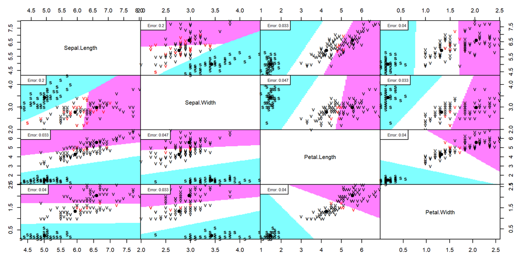

# Iris All Features

## LDA based on four features: Performance

- Use lda function in MASS library to do LDA using all features.

```r
lda.iris = lda(Species ~ ., data = iris)
con.mat=table(Pred = predict(lda.iris, iris)$class,
              True = iris$Species)
#Confusion Matrix
con.mat
```

```
            True
Pred         setosa versicolor virginica
  setosa         50          0         0
  versicolor      0         48         1
  virginica       0          2        49
```

```r
#Training Error
1-sum(diag(con.mat))/sum(con.mat)
```

```
[1] 0.02
```

### Iris All Features (1st LD): Performance

```r
lda.iris = lda(Species ~ ., data = iris)
con.mat=table(Pred = predict(lda.iris, iris, dimen=1)$class,
              True = iris$Species)
#Confusion Matrix
con.mat
```

```
            True
Pred         setosa versicolor virginica
  setosa         50          0         0
  versicolor      0         48         0
  virginica       0          2        50
```

```r
#Training Error
1-sum(diag(con.mat))/sum(con.mat)
```

```
[1] 0.01333333
```

### Visualize the LDA

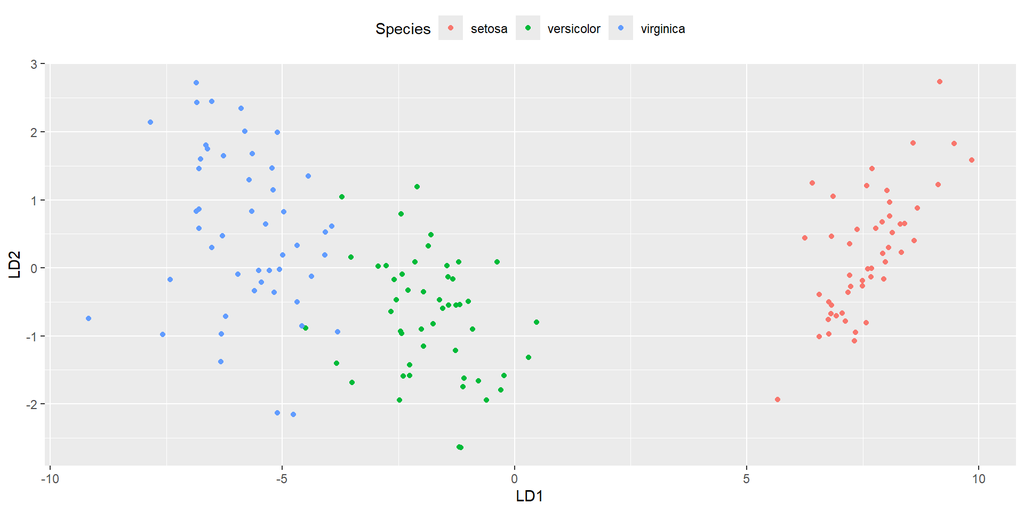

```r
lda.iris.data=data.frame(Species=iris$Species, predict(lda.iris, iris)$x)
ggplot(lda.iris.data, aes(x=LD1, y=LD2, color=Species)) +
  geom_point() +
  labs(x="LD1", y="LD2") +
  theme(legend.position = "top")
```

### Visualize the LDA: LD1

```r
lda.iris.scores=predict(lda.iris)
ldahist(lda.iris.scores$x[,1], g=iris$Species, xlab="LDA1")
```

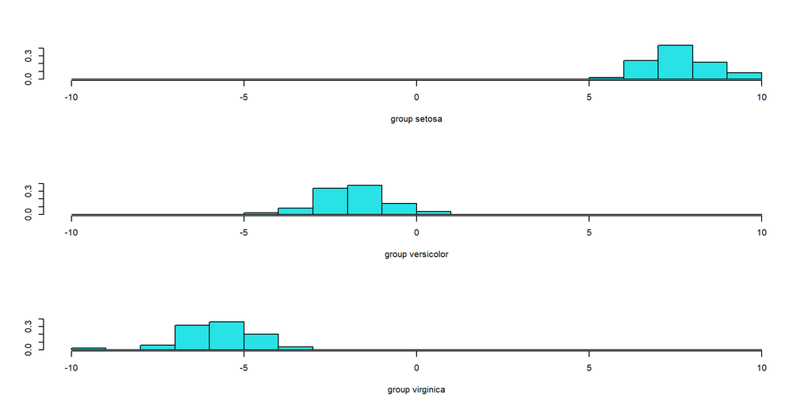

### Visualize the LDA: LD2

```r
lda.iris.scores=predict(lda.iris)
ldahist(lda.iris.scores$x[,2], g=iris$Species, xlab="LDA1")
```

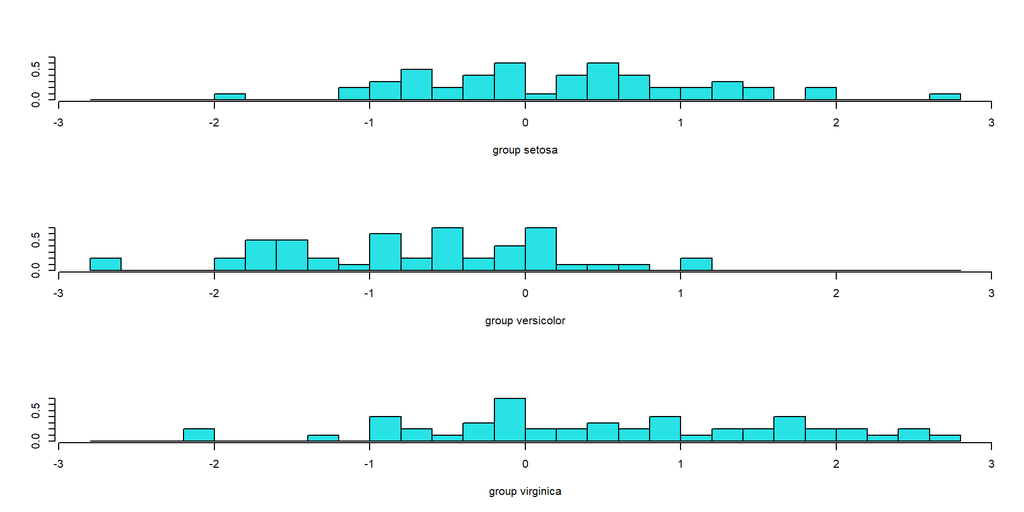

## Iris Data: PCA vs LDA

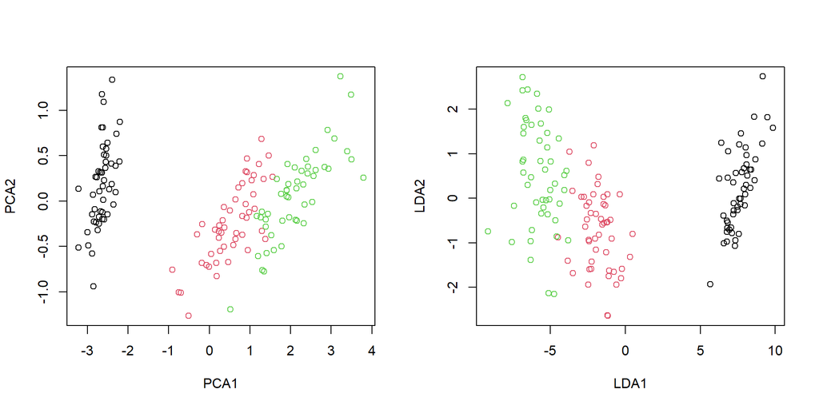

```r
lda.iris = lda(Species ~ ., data = iris)
pca.iris = princomp(iris[,1:4], cor = FALSE, scores = TRUE)
par(mfrow=c(1,2))
plot(pca.iris$scores[,1:2], xlab="PCA1", ylab="PCA2")
points(pca.iris$scores[51:100,1:2], col=2)
points(pca.iris$scores[101:150,1:2], col=3)
plot(predict(lda.iris, iris)$x, xlab="LDA1", ylab="LDA2")
points(predict(lda.iris, iris)$x[51:100,], col=2)
points(predict(lda.iris, iris)$x[101:150,], col=3)
```

# Multi-Class LDA

## Extend FLDA to $g$ Classes

- Consider $g$ classes. We have $g$ independent random samples:
  $$\begin{aligned}
  X_{1j} & \overset{iid}\sim (\mu_1, \Sigma), j=1, \cdots, n_1\\
  X_{2j} & \overset{iid}\sim (\mu_2, \Sigma), j=1, \cdots, n_2\\
  \cdots & \cdots \\
  X_{gj} & \overset{iid}\sim (\mu_g, \Sigma), j=1, \cdots, n_g
  \end{aligned}$$
- Want to find a linear function $Y_{ij}^{(1)}=a^T X_{ij}$ that leads to maximum separation

## Separation in a $g$-Class Problem

- Measure separation using F statistic

$$\begin{aligned}
F(a) &= \frac{MSB}{MSW}=\frac{SSB/(g-1)}{SSW/(n-g)}\\
&= \frac{\sum_{i=1}^g n_i (\bar Y_{i.}^{(1)} -\bar Y_{..}^{(1)})^2/(g-1)}{\sum_{i=1}^g (n_i-1)S_{Y_i^{(1)}}^2/(n-g)}\\
&=\frac{a^T \sum n_i (\bar X_{i.} -\bar X_{..})(\bar X_{i.}-\bar X_{..})^T a}{a^T \sum_{i=1}^g\sum_{j=1}^{n_i} (X_{ij} -\bar X_{i.})(X_{ij}-\bar X_{i.})^T a}\frac{n-g}{g-1}\\
&= \frac{a^T \mathbf B a}{a^T \mathbf W a}\frac{n-g}{g-1}
\end{aligned}$$
where $n=\sum_{i=1}^g n_i$, $\mathbf B$ is the between-group sample covariance matrix, and $\mathbf W$ is the within-group sample covariance matrix.

## Linear Discriminants

- The first linear discriminant is the linear function that maximizes $F(a)$. It can also be shown that the first linear discriminant is given by the first eigenvector of $\mathbf W ^{-1} \mathbf B$, i.e.,
  $$Y_{ij}^{(1)}=\gamma_1^T X_{ij}$$
  where $\gamma_1$ is the first eigenvector of $\mathbf W ^{-1} \mathbf B$.
- Similarly, for $k=1, \cdots, rank(\mathbf B)$, the $k$th linear discriminant is given by the $k$th eigenvector of $\mathbf W ^{-1} \mathbf B$

$$Y_{ij}^{(k)}=\gamma_k^T X_{ij}$$

## Use the Linear Discriminants

- Allocate an observation to the group with the minimum distance defined by the Euclidean distance in space spanned by the linear discriminants.
- Let $X_0$ be a new observation.
- Calculate $Y_0^{(k)}=\gamma_k^T X_0$, the projection of $X_0$ to the $k$th linear discriminant for $k=1, \cdots, rank(B)$.
- Calculate the distance between $(Y_0^{(1)}, \cdots, Y_0^{(rank(B))})$ and $(\bar Y_{i.}^{(1)}, \cdots, \bar Y_{i.}^{(rank(B))})$

$$D^2(X_0, i) = \sum_{k=1}^{rank(B)} [Y_0^{(k)} - \bar Y_{i.}^{(k)}]^2$$
- Allocate $X_0$ to
$$\operatorname*{argmin}_i D^2(X_0, i)$$

## The Number of Linear Discriminants

- Recall that $rank(B)=min(p, g-1)$ (Lecture 8). The number of total linear discriminants is $min(p,g-1)$.
- In the two-class, $rank(B)=1$. Thus, there is only one linear discrminant.
- When $rank(B)$ is large, it is often helpful to use the top linear discriminants.
- A scree plot of the eigenvalues of $\mathbf W^{-1}\mathbf B$ can be used to find an elbow point, if there is one

# Example: Glasses

## Example: Glasses

```r
#install.packages("mlbench")
data(Glass, package = "mlbench")
table(Glass$Type)

glass_subset <- Glass[Glass$Type %in% c(1,2,6,7), ]
glass_subset$Type <- factor(glass_subset$Type)
# Fit LDA model
lda_model <- lda(Type ~ ., data = glass_subset)

# Print LDA results
lda_model

# Plot LDA results
plot(lda_model)

# Predict classes using LDA
predictions <- predict(lda_model, glass_subset)

# Confusion matrix (actual vs. predicted)
conf_matrix <- table(Actual = glass_subset$Type, Predicted = predictions$class)
print(conf_matrix)

# Calculate accuracy
accuracy <- sum(diag(conf_matrix)) / sum(conf_matrix)
cat("Accuracy:", round(accuracy * 100, 2), "%\n")


# Extract LD scores
ldahist(predictions$x[,1], g=glass_subset$Type)


# Vary number of LDs
predictions <- predict(lda_model, glass_subset, dimen=1)
conf_matrix <- table(Actual = glass_subset$Type, Predicted = predictions$class)
accuracy1 <- sum(diag(conf_matrix)) / sum(conf_matrix)

predictions <- predict(lda_model, glass_subset, dimen=2)
conf_matrix <- table(Actual = glass_subset$Type, Predicted = predictions$class)
accuracy2 <- sum(diag(conf_matrix)) / sum(conf_matrix)

predictions <- predict(lda_model, glass_subset, dimen=3)
conf_matrix <- table(Actual = glass_subset$Type, Predicted = predictions$class)
accuracy3 <- sum(diag(conf_matrix)) / sum(conf_matrix)

predictions <- predict(lda_model, glass_subset, dimen=4)
conf_matrix <- table(Actual = glass_subset$Type, Predicted = predictions$class)
accuracy4 <- sum(diag(conf_matrix)) / sum(conf_matrix)


cat("Accuracy with 1 LD:", round(accuracy1 * 100, 2), "%\n")
cat("Accuracy with 2 LDs:", round(accuracy2 * 100, 2), "%\n")
cat("Accuracy with 3 LDs:", round(accuracy3 * 100, 2), "%\n")
cat("Accuracy with 4 LDs:", round(accuracy4 * 100, 2), "%\n")
```

[output not shown]

# Further Reading/Topics

## Further Reading/Topics

- Cross validation in LDA
  - the lda function in R has an option to do leave one out cross validation
- Better visualization of classification results
  - R package: WeDiBaDis
  - https://uw.pressbooks.pub/appliedmultivariatestatistics/chapter/discriminant-analysis/
- LDA with unequal covariance matrices
- Quadratic Discriminant Analysis (QDA)

# Additional Example: Crude Oil

```r
urlfile='https://raw.githubusercontent.com/yu-zhaoxia/teaching-multivariate/d87ce8b30ecb15fc09aa543047b3b0076c22cc25/CrudeOil.txt'
co=read.table(urlfile, header=F)
names(co)=c("V1","V2","V3","V4","V5","type")
```

- Exploratory analysis shows that transformation might be helpful

```r
co[,2]=sqrt(co[,2])
co[,3]=sqrt(co[,3])
co[,4]=1/co[,4]
```

```r
obj=lda(type~V1+V2+V3+V4+V5, data=co)
ld=predict(obj, co)$x
ld1=ld[,1]
ld2=ld[,2]

T=(56-1)*cov(co[,1:5])
W=(7-1)*cov(co[1:7,1:5]) +(11-1)*cov(co[8:18,1:5])+
  (38-1)*cov(co[19:56,1:5])
B=T-W
lambda=eigen(solve(W)%*%B)$values
lambda[abs(lambda)<1.0e-10]=0
lambda=Re(lambda)
```

## Example Crude Oil

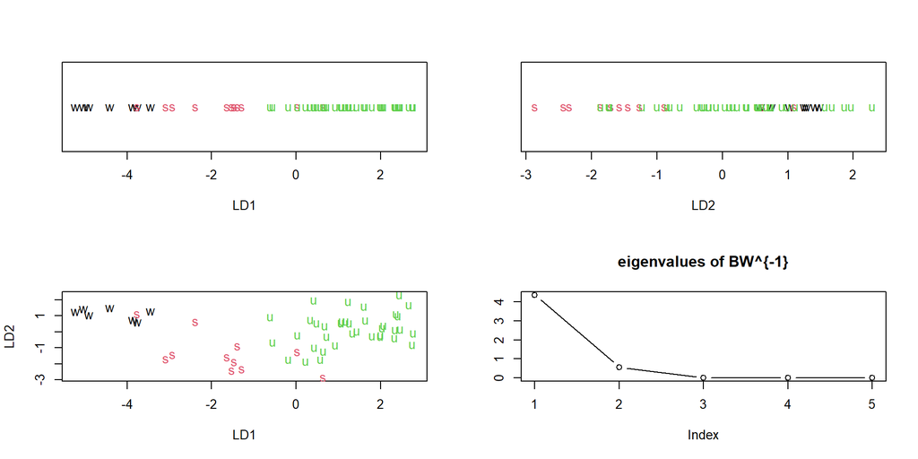

```r
par(mfrow=c(2,2))
par(yaxt="n")
plot(ld1, rep(0,56), xlab="LD1", ylab="", type="n")
points(ld1[1:7], rep(0, 7), pch="w", col=1)
points(ld1[8:18], rep(0, 11), pch="s", col=2)
points(ld1[19:56], rep(0, 38), pch="u", col=3)

plot(ld2, rep(0,56), xlab="LD2", ylab="", type="n")
points(ld2[1:7], rep(0, 7), pch="w", col=1)
points(ld2[8:18], rep(0, 11), pch="s", col=2)
points(ld2[19:56], rep(0, 38), pch="u", col=3)

par(yaxt="t")
plot(ld1, ld2, xlab="LD1", ylab="LD2", type="n")
points(ld1[1:7], ld2[1:7], pch="w", col=1)
points(ld1[8:18], ld2[8:18], pch="s", col=2)
points(ld1[19:56], ld2[19:56], pch="u", col=3)

#### scree plot
plot(lambda, type="b", ylab="", main="eigenvalues of BW^{-1}")
```